# Predicting Classifications

Associate Professor Ole Maneesoonthorn

Predictive Analytics, Term 4 2020

## Energy Consumer Sentiment Survey

### Predicting intention to switch energy provider

Energy Consumer Australia is an independent organization representing energy consumers from the residential and small business owners sectors. One of its projects is to conduct bi-annual Energy Consumer Sentiment survey. This data can be used to help retail energy providers to understand the attitudes of energy consumers and the drivers of their intention to switch companies.

We focus on predicting the variable “Switch”, which is a response to whether a particular consumer is intending to switch provider within the next year. The predictive model for this variable aids the provider to identify customers who have high chance of switching to a competitor. Once identified, they can take intervention steps to attempt to retain these customers.

The data is gathered for you in an R workspace called “energyData.RData”. Let us load the relevant libraries and data in now.

```r
library(tidyverse)
library(caret)
# for ROC curve
library(pROC)
# for variable importance
library(vip)

load("energyData.RData")
```

This file consists of two dataset: December 2019 survey and June 2020 survey. We will focus on the December 2019 survey for this work through, and you will be investigating the June 2020 data in your syndicate tasks. Both dataframes contain the following input variables:

- Employment = the respondent’s employment status. This is a factor variable with seven levels
  1. Self-employed
  2. full-time
  3. part-time
  4. home duties
  5. retired
  6. unemployed
  7. student
- DecRole = the respondent’s decision role within the household. This is a factor variable with two levels
  1. main - the respondent is the main decision maker in their household in relation to choosing energy products and services.
  2. joint - the respondent is a joint decision maker in their household in relation to choosing energy products and services.
- Gender = the respondent’s gender. This is a factor variable with two levels
  1. Male
  2. Female
- Age = the respondent’s age group. This is a factor variable with eight levels
  1. 18-24
  2. 25-34
  3. 35-44
  4. 45-54
  5. 55-64
  6. 65-74
  7. 75+
  8. Prefer not to answer
- AHInc = the respondent’s Annual Household Income. This is a factor variable with eight levels
  1. Less than $20,000
  2. $20,000 to under $40,000
  3. $40,001 to under $60,000
  4. $60,001 to under $80,000
  5. $80,001 to under $100,000
  6. $100,001 to under $120,000
  7. $120,001 to under $150,000
  8. $150,001 or more
- Educ = the respondent’s education level. This is a factor variable with five levels
  1. Did not complete Year 12
  2. Completed Year 12
  3. Trade/TAFE
  4. Diploma
  5. University Degree
- DepChildren = indicate whether the respondent has any dependent children under the age of 18. This is a factor variable with two levels
  1. No
  2. Yes
- HouseType = the responden’t dwelling type. This is a factor variable with four levels
  1. house
  2. townhouse/duplex
  3. unit
  4. other
- PeopleInHH = the number of people in the respondent’s household. This is a numeric variable.
- OwnOrRent = indicate whether the respondent owns the dwelling they live in. This is a factor variable with two levels
  1. No
  2. Yes
- BillLargerThanExp = indicate whether the respondent’s energy bill was larger than expected. This is a factor variable with two levels
  1. No
  2. Yes
- BillPressure = indicate whether the energy bill causes financial pressure in household. This is a factor variable with two levels
  1. No
  2. Yes

Satisfaction scores on various aspects of the energy account are also recorded. These satisfaction scores are on 11-point scale with 1 being very dissatisfied and 11 being very satisfied, and are recorded a numeric values. These are:

- VoMSat = Value of money on energy account in the past 6 months
- OverallCSE6mth = Overall customer service in past 6 months
- BillSat = Bill and accounts in past 6 months
- BlackoutsSat = Occurrences of blackouts in past 6 months

Our output variable of interest is Switch, which indicates whether a respondent is intending to switch energy provider over the next year.

### Accuracy metrics and data conversion

In this section, we first take care of the definition of the accuracy metrics for binary classification and converting the data structure for use in our more sophisticated models.

**Predictive Accuracy Metrics**

The function “labelAccuracy” summarizes the statistical accuracy metrics of binary classification. The inputs are y=test data, prob=predicted probability for each row of the test data, cutoff=the cutoff probability for classification, and showplot=TRUE/FALSE indicating whether you wish to generate the plot of the ROC curve.

```r
#Function to calculate statistical accuracy metrics of binary classification
#INPUTS: y=test data "No" or "Yes"
#prob=predicted probability of a "Yes" for each row of test data
#cutoff=cutoff probability for predicting the classification
# e.g. predicted outcome = Yes if prob>cutoff
#showplot=TRUE/FALSE indicating whether a plot of the ROC curve should be produced
labelAccuracy <- function(y,prob,cutoff,showplot){
    #Hit and miss table
    HM <- matrix(0,2,2)
    colnames(HM) <- c("Actual y='Yes'", "Actual y='No'")
    rownames(HM) <- c("Predicted y='Yes'", "Predicted y='No'")
    HM[1,1] <- mean(prob>cutoff & y=="Yes", na.rm=TRUE)
    HM[1,2] <- mean(prob>cutoff & y=="No", na.rm=TRUE)
    HM[2,1] <- mean(prob<=cutoff & y=="Yes", na.rm=TRUE)
    HM[2,2] <- mean(prob<=cutoff & y=="No", na.rm=TRUE)

    #Storage for various accuracy measures
    metrics=matrix(0,1,6)
    colnames(metrics)=c("Overall","Precision","Sensitivity",
                        "Specificity","AUC","Gini")
    metrics[1,"Overall"]=sum(diag(HM))
    metrics[1,"Precision"]=HM[1,1]/sum(HM[1,])
    metrics[1,"Sensitivity"]=HM[1,1]/sum(HM[,1])
    metrics[1,"Specificity"]=HM[2,2]/sum(HM[,2])

    #Construct ROC to calculate AUC and Gini
    #Show plot only if input showplot==TRUE
    #These metrics do not vary with the cutoff level
    # ROC curve
    fit.ROC <- roc(y~prob, plot=showplot, print.auc=TRUE,quiet=TRUE)
    metrics[1,"AUC"]=fit.ROC$auc
    metrics[1,"Gini"]=2*fit.ROC$auc-1

    #Function returns a list, including the hit and miss table
    #the summary metrics and the ROC curve object
    return(list(HitMiss=HM,Metrics=metrics,ROC=fit.ROC))
}
```

**Data conversion and split**

First, we define the block of data to use. We will investigate the predictive model performance using December 2019 data. This block of code also splits the data into training and test set using 80/20 split.

```r
energy=dec19

set.seed(123)
train_index <- sample(1:nrow(energy), 0.8 * nrow(energy))

# Split data into training and testing set
trainData <- energy[train_index,]
testData <- energy[-train_index,]

# Check the data definition for classification
contrasts(testData$Switch)
```

```
##     Yes
## No    0
## Yes   1
```

We also need to convert the data to numeric for some of the models, including neural network and boosting. The data block “energy_scaled” contains dummy (0/1) records of each of the factor variables, as well as scaled numeric data.

```r
energy_scaled <- energy

# change categorical variables to dummy
catVar <- model.matrix(~Employment+DecRole+
                        Gender+Age+AHInc+Educ+
                        DepChildren+OwnOrRent+BillLargerThanExp+
                        BillPressure+HouseType, data = energy_scaled)[,-1]

# scale continuous variables
for (i in 9:13){
    energy_scaled[,i] <- as.numeric(scale(energy_scaled[,i]))
}

# combining dummy and scaled variables
energy_scaled <- cbind(energy_scaled[, 9:13], catVar,
                       energy_scaled[,"Switch"])

# rename variables as the existing name is too long
names(energy_scaled)[] <- c("PeopleInHH", "VoMSat_Elec", "OverallCSE6mth",
                            "BillSatElec", "BlackoutSatElec", "EmpFT", "EmpPT",
                            "EmpHome", "EmpRetired",
                            "EmpUnemployed", "EmpStudent", "JointDecMaker",
                            "Female","Age25_34","Age35_44", "Age45_54",
                            "Age55_64", "Age65_74","Age75", "AgeNoAns", "Income20k",
                            "Income40k", "Income60k", "Income80k",
                            "Income100k", "Income120k", "Income150k",
                            "EducYear12", "EducTAFE", "EducDiploma",
                            "EducUniversity", "DepChildrenY",
                            "OwnHomeY", "BillLargerThanExp", "BillPressureY",
                            "Townhouse","Unit","OtherHouseType",
                            "Switch")

# Split data
trainData_scaled <- energy_scaled[train_index,]
testData_scaled <- energy_scaled[-train_index,]
```

### Modeling the probability of “Switch”

Now we can apply the predictive modeling to assess which model performs best at predicting consumer’s intention to switch energy provider. We will explore the following models:

- The naive prediction - no input variables are used here.
- Logistic regression
- Decision tree
- Neural network
- K-nearest neighbour
- Bagging
- Random forest
- Boosting

**Naive Prediction**

In the case where no input variables are used, the best prediction is the proportion of consumers who have indicated that they intend to switch provider. Since 15.4% of consumers indicate that would switch, this naive prediction will predict a “No” to all participants in the test set (probability of switch is lower than the cut-off point of 50%).

Note here that precision is reported as “NaN”, as no “Yes” cases are predicted. You should also note that AUC=0.5 and Gini=0 by definition.

```r
#The naive prediction....
pnaive=sum(trainData$Switch=='Yes')/nrow(trainData)

# Assessing model accuracy
naiveAcc=labelAccuracy(testData$Switch,replicate(nrow(testData),pnaive),0.5,TRUE)
```

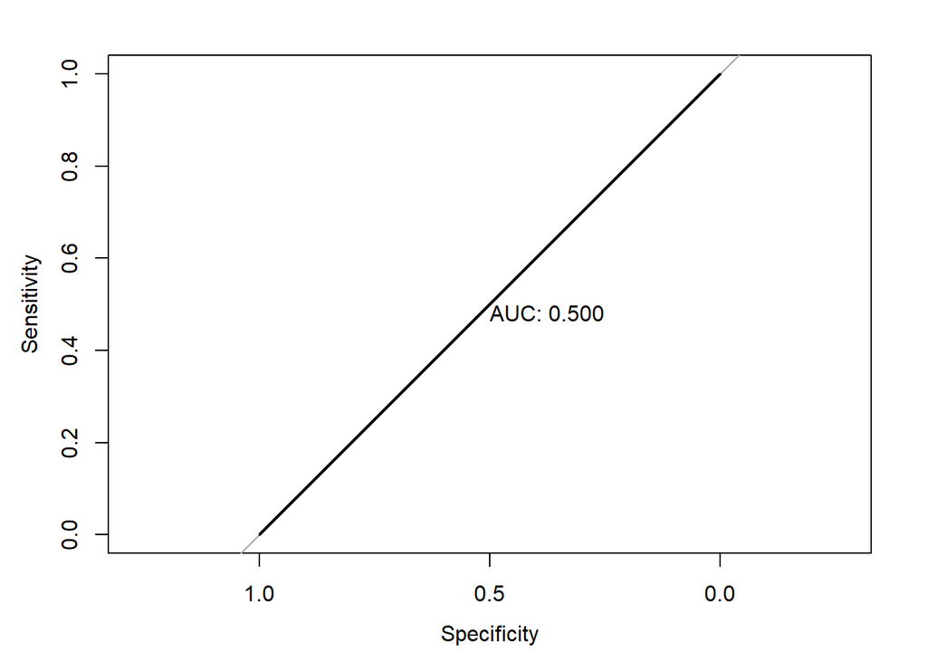

```r
naiveAcc$Metrics
```

```
##        Overall Precision Sensitivity Specificity AUC Gini
## [1,] 0.8737624       NaN           0           1 0.5    0
```

**Logistic Regression**

Let us bring in the input data and construct a logistic regression model. Since many of the variables are factor variables and the model is constructed using binary dummy variable for each of the factor, the model is rather large. This makes the model summary relatively difficult to read. As such, summarizing the results using the variable importance (vip) plot is useful as it gives the top ten most important variables. We can then look into the coefficients of these variables to assess what kind of relationship is present.

```r
#Train the logistic regression using the glm() function
fit1 <- glm(Switch~., data = trainData, family=binomial)
#A summary of the fit
summary(fit1)
```

```
##
## Call:
## glm(formula = Switch ~ ., family = binomial, data = trainData)
##
## Deviance Residuals:
##     Min       1Q   Median       3Q      Max
## -1.4103  -0.5989  -0.4326  -0.2840   2.8312
##
## Coefficients:
##                                 Estimate Std. Error z value Pr(>|z|)
## (Intercept)                     -0.55733    1.22638  -0.454 0.649503
## Employmentfull-time              0.40107    1.07214   0.374 0.708345
## Employmentpart-time              0.28368    1.08373   0.262 0.793504
## Employmenthome duties            0.62666    1.08466   0.578 0.563438
## Employmentretired                0.33893    1.08231   0.313 0.754162
## Employmentunemployed             0.04590    1.11123   0.041 0.967053
## Employmentstudent                0.31411    1.15550   0.272 0.785746
## DecRolejoint                    -0.41424    0.17167  -2.413 0.015824 *
## Genderfemale                     0.02833    0.16605   0.171 0.864537
## Age25-34                        -0.88203    0.44451  -1.984 0.047227 *
## Age35-44                        -0.72123    0.42165  -1.710 0.087175 .
## Age45-54                        -1.07492    0.43073  -2.496 0.012576 *
## Age55-64                        -0.64673    0.43796  -1.477 0.139756
## Age65-74                        -0.79413    0.48683  -1.631 0.102841
## Age75+                          -1.93035    0.65787  -2.934 0.003343 **
## AHInc$20,000 to under $40,000   -0.25888    0.30174  -0.858 0.390914
## AHInc$40,001 to under $60,000    0.24260    0.32269   0.752 0.452170
## AHInc$60,001 to under $80,000   -0.26179    0.34914  -0.750 0.453374
## AHInc$80,001 to under $100,000  -0.04444    0.36352  -0.122 0.902697
## AHInc$100,001 to under $120,000 -0.12482    0.40340  -0.309 0.757001
## AHInc$120,001 to under $150,000  0.20783    0.38293   0.543 0.587314
## AHInc$150,001 or more            0.36977    0.39179   0.944 0.345268
## EducCompleted Year 12           -0.11793    0.27692  -0.426 0.670209
## EducTrade/TAFE                   0.12229    0.25847   0.473 0.636117
## EducDiploma                      0.19258    0.29016   0.664 0.506869
## EducUniversity Degree            0.51484    0.24527   2.099 0.035810 *
## DepChildrenYes                   0.83813    0.23635   3.546 0.000391 ***
## HouseTypetownhouse/duplex       -0.28942    0.29700  -0.974 0.329832
## HouseTypeunit                    0.21376    0.21841   0.979 0.327728
## HouseTypeother                  -0.66922    1.07247  -0.624 0.532632
## PeopleInHH                      -0.07918    0.07670  -1.032 0.301919
## VoMSat                          -0.02627    0.04279  -0.614 0.539343
## OverallCSE6mth                  -0.12844    0.05375  -2.389 0.016877 *
## BillSat                          0.03489    0.04944   0.706 0.480340
## BlackoutsSat                    -0.04248    0.03101  -1.370 0.170699
## OwnOrRentYes                    -0.00426    0.18190  -0.023 0.981315
## BillLargerThanExpYes             0.62791    0.16666   3.768 0.000165 ***
## BillPressureYes                  0.25556    0.17479   1.462 0.143700
## ---
## Signif. codes:  0 '***' 0.001 '**' 0.01 '*' 0.05 '.' 0.1 ' ' 1
##
## (Dispersion parameter for binomial family taken to be 1)
##
##     Null deviance: 1387.9  on 1612  degrees of freedom
## Residual deviance: 1228.5  on 1575  degrees of freedom
## AIC: 1304.5
##
## Number of Fisher Scoring iterations: 5
```

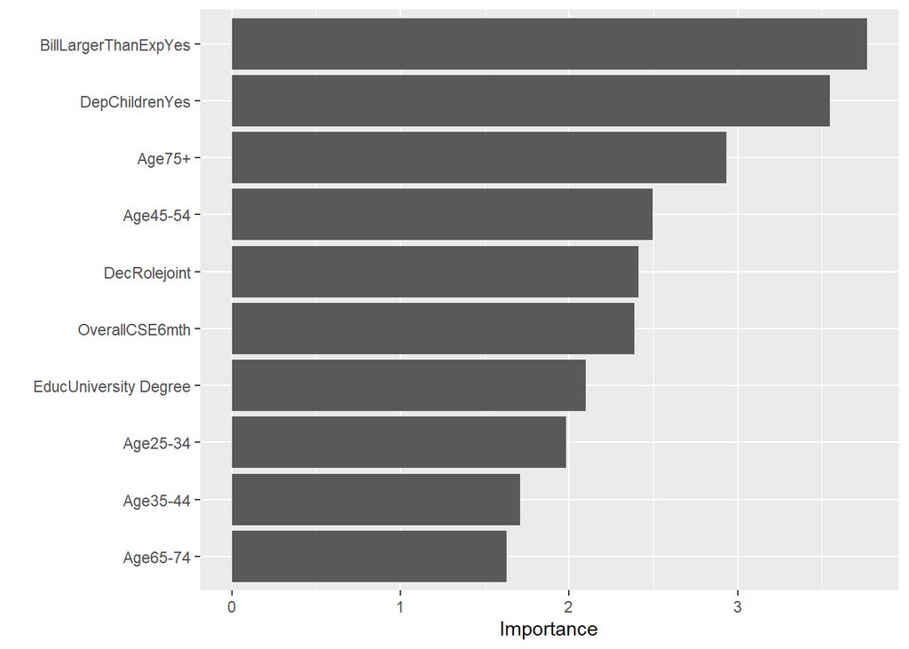

```r
#Summarizing the variable importance graphically
vip(fit1)
```

The variable importance plot reveals that the key factors in determining a consumer’s likelihood to switch provider are the size of the bill, whether they have dependent children, age, their overall consumer satisfaction score in the last six months, and whether they have university degree. In summary, consumers whose bill has been larger than expected, consumers who have dependent children and consumers who have university degrees are more likely to indicate the intention to switch providers. Older consumers are less likely to respond with an intention to switch relative to the 18-24 year old age group. The model also reveals that if the consumer give higher satisfaction scores, they are less likely to respond with an intention to switch.

It is important to note that we can only comment on the directional relationship here, and cannot directly interpret the logistic regression coefficients as direct impact on the probability of switch.

Let us assess the predictive power of the logistic regression over the test set. Predictive probabilities can be calculated using the predict() function below.

```r
# Predicting y for the test set
pfit1 <- predict(fit1, newdata = testData, type="response")

# Assessing model accuracy with cutoff threshold of 0.5
fit1Acc=labelAccuracy(testData$Switch,pfit1,0.5,TRUE)
```

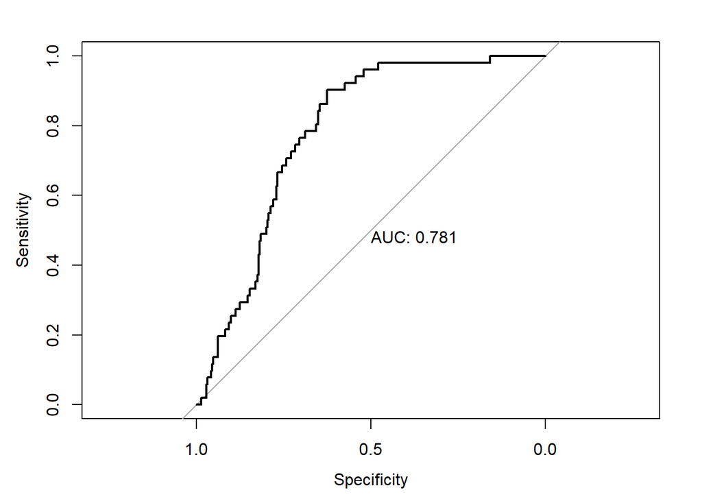

```r
fit1Acc$Metrics
```

```
##        Overall Precision Sensitivity Specificity      AUC      Gini
## [1,] 0.8638614         0           0   0.9886686 0.781092 0.5621841
```

Despite having reasonable overall accuracy of 86% and AUC and Gini that are well above zero, the logistic regression fails to predict any positive cases at the neutral cutoff of 0.5! This is revealed by zero precision and sensitivity measures. We will explore the alternative models to see if they provide better predictions.

**Decision Tree**

Here we will construct the decision tree. You will note that the R syntax to construct the tree is exactly the same as before, but with the additional input of method=“class” to indicate to the command that this is a classification problem. In the code below, we construct the visualization of the tree as well as the variable importanct plot.

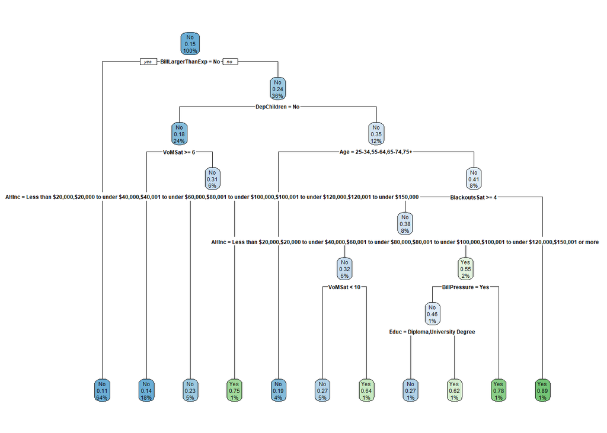

```r
library(rpart)
library(rpart.plot)

# Building the decision tree for classification
fit2 <- rpart(Switch ~ ., data = trainData, method  = "class")

# Visualizing the tree
rpart.plot(fit2)
```

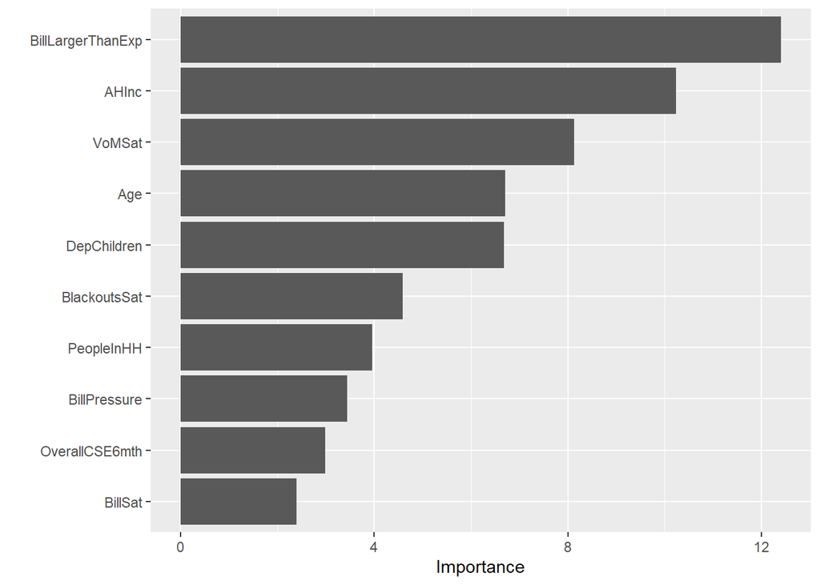

```r
vip(fit2)
```

The visualization of the tree is rather difficult to read in detail, but we can see that the variables that form the root is whether the consumer’s bill was larger than expected. Like the logistic context, age, whether the consumer has dependent children and education level also feature in the tree. The decision tree also suggests that annual household income and value for money satisfaction also feature prominently.

Evaluating the predictions using the test data:

```r
# Predicting y for the test set
pfit2 <- predict(fit2, newdata=testData, type="prob")

# Assessing model accuracy
fit2Acc=labelAccuracy(testData$Switch,pfit2[,"Yes"],0.5,TRUE)
```

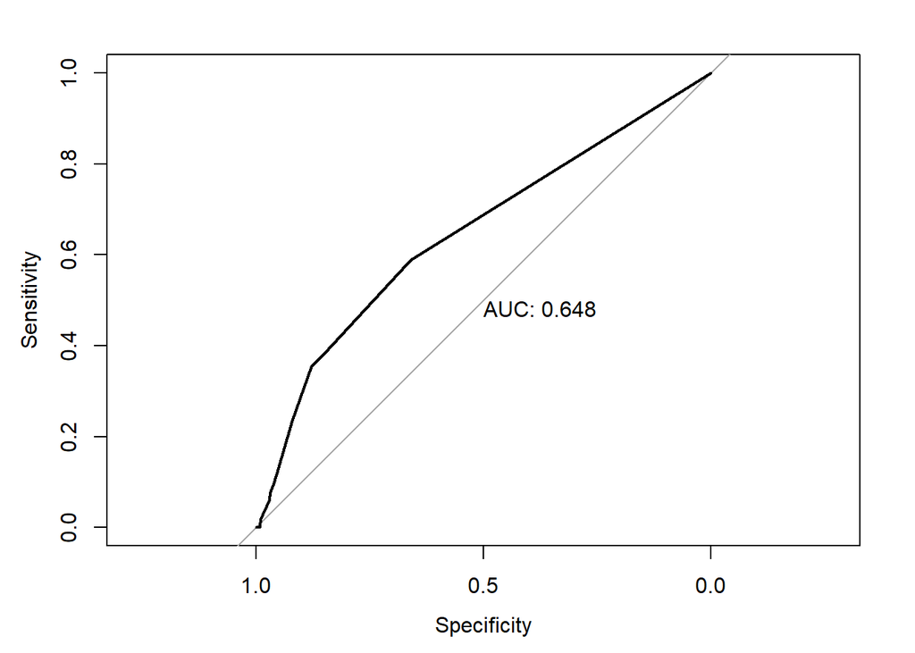

```r
fit2Acc$Metrics
```

```
##        Overall Precision Sensitivity Specificity       AUC      Gini
## [1,] 0.8514851 0.2631579  0.09803922   0.9603399 0.6475032 0.2950064
```

The predictive accuracy metrics produced above shows that the decision tree performs better in terms of precision and sensitivity than the logistic regression at the cutoff level of 0.5, even though the AUC and Gini index are smaller.

**Neural Network**

In this section, we train the neural network to predict the No/Yes responses for the consumer’s intention to switch. One hidden layer is used, with 4 hidden nodes in that layer for this example. It is important to remember that neural networks only take numeric variables, so all factors must be converted to 0/1 binary numbers. In addition, we also need to scale all other numeric variables to have zero mean and unit variance for stability of the weights within the neural network.

The neural network considers this a problem with two class: No and Yes. Only the Olden variable importance can be used here as the Garson method is only suitable for single outputs.

```r
library(neuralnet)
library(NeuralNetTools)
#Set the random seed and train the neural network
set.seed(123)
fit3 <- neuralnet(Switch~., data=trainData_scaled, hidden=4,
                  linear.output = FALSE)

#Olden's variable importance
fit3olden=olden(fit3,out_var='Yes')
fit3olden$data
```

|  | importance | x_names |
| --- | --- | --- |
| 36 | -18368.45287 | Townhouse |
| 24 | -18228.82326 | Income80k |
| 25 | -17213.85840 | Income100k |
| 26 | -17160.87207 | Income120k |
| 7 | -5772.17173 | EmpPT |
| 19 | -2801.89923 | Age75 |
| 15 | -1157.19850 | Age35_44 |
| 12 | -1133.09113 | JointDecMaker |
| 18 | -841.41010 | Age65_74 |
| 23 | -815.51354 | Income60k |

[output cut: 28 more lines]

Since there are many input variables here, the plot generated by the olden() function is not legible on the horizon axis. So, instead of looking at the plot, we can look at the actual importance index the function generates. Remember that the Olden method retains the signs of the weight of each variable, so we look for importance index with greatest magnitude to identify which variable is most important. Surprisingly, house type plays a significant role, so does income, age and whether the consumer is in a joint decision making role. This conclusion is quite different to the previous two models.

Let’s look at the predictive performance of the neural network when applied to the test set data.

```r
# Predicting y for the test set
pfit3 <- predict(fit3, newdata=testData_scaled)
# Assessing model accuracy
fit3Acc=labelAccuracy(testData$Switch,pfit3[,2],0.5,TRUE)
```

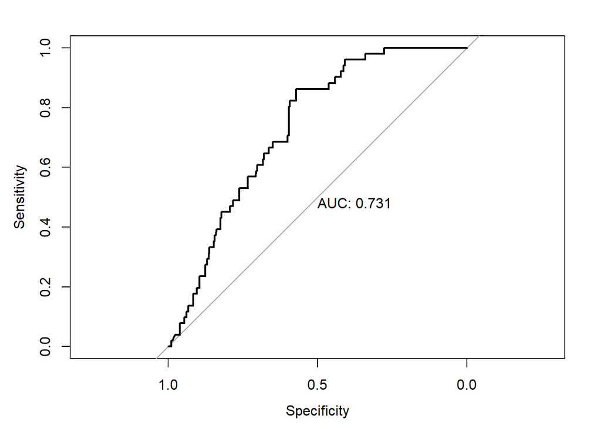

```r
fit3Acc$Metrics
```

```
##        Overall Precision Sensitivity Specificity       AUC      Gini
## [1,] 0.8168317 0.2195122   0.1764706   0.9093484 0.7314614 0.4629228
```

Compared to decision tree, neural network is more accurate according to the sensitivity measure, but less accurate in terms of precision. The AUC and Gini index both indicate that neural network perform better than decision tree, but is still not as good as the logistic regression.

**K-Nearest Neighbour**

The only unsupervised learning algorithm that we will apply to this case is the k-NN classification algorithm. Since most of our input variables are factor variables, k-means is not appropriate in this case.

The code below trains the k-NN algorithm using the knn3() function from the “caret” library. As with the k-NN regression case, there is no summary that would be meaningful for interpretation from the algorithm, so the only way we can evaluate the output is by using prediction.

```r
#Train the k-NN classification here.
#The knn3 function is from the caret library, and it returns predicted probabilities for all classes within the dataset.
fit4 <- knn3(Switch~., data=trainData_scaled,
             k=as.integer(sqrt(nrow(trainData))))

# Predicting y for the test set
pfit4 <- predict(fit4, newdata=testData_scaled, type="prob")
# Assessing model accuracy
fit4Acc=labelAccuracy(testData$Switch,pfit4[,"Yes"],0.5,TRUE)
```

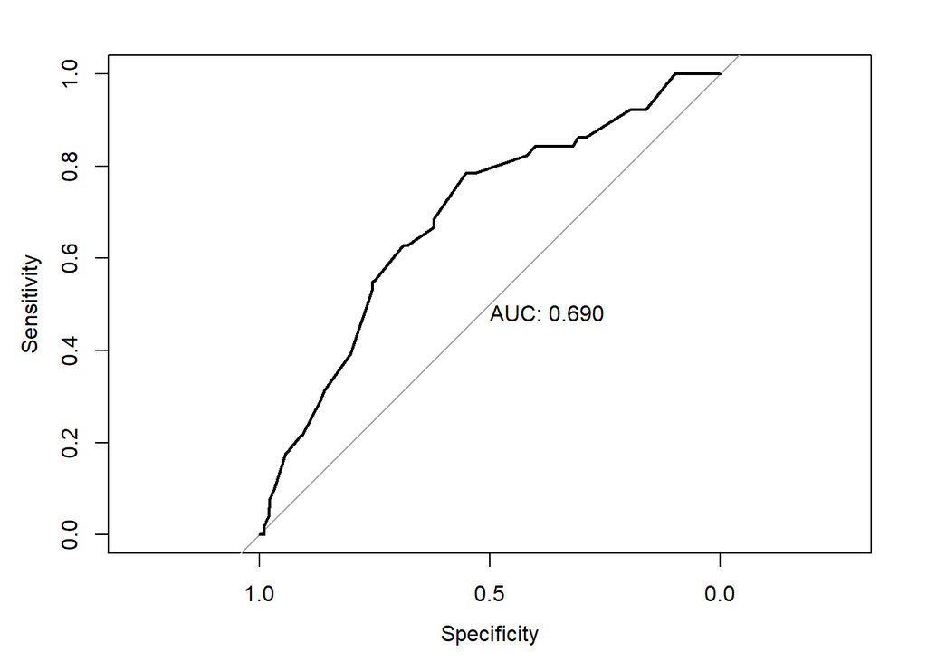

```r
fit4Acc$Metrics
```

```
##        Overall Precision Sensitivity Specificity       AUC      Gini
## [1,] 0.8737624       NaN           0           1 0.6898017 0.3796034
```

The accuracy metrics reveal that the k-NN algorithm fails to predict any “Yes” responses for the test set at the cutoff probability of 0.5, resulting in “NaN” precision and zero sensitivity. The AUC and Gini index still indicate that the model has some predictive power.

**Bagging**

The first of the ensemble methods that we will explore is bagging with a decision tree as the base learner. The package “caret” recognizes and works with factor variables. We also produce the variable importance plot to analyse which of the input variables play key roles in determining the likelihood of an intention to switch.

```r
#Set the random seed and train the bagging algorithm
set.seed(123)
fit5 <- train(Switch~., data = trainData, method='treebag',
              metric="Accuracy")
print(fit5)
```

```
## Bagged CART
##
## 1613 samples
##   16 predictor
##    2 classes: 'No', 'Yes'
##
## No pre-processing
## Resampling: Bootstrapped (25 reps)
## Summary of sample sizes: 1613, 1613, 1613, 1613, 1613, 1613, ...
## Resampling results:
##
##   Accuracy   Kappa
##   0.8196321  0.07362993
```

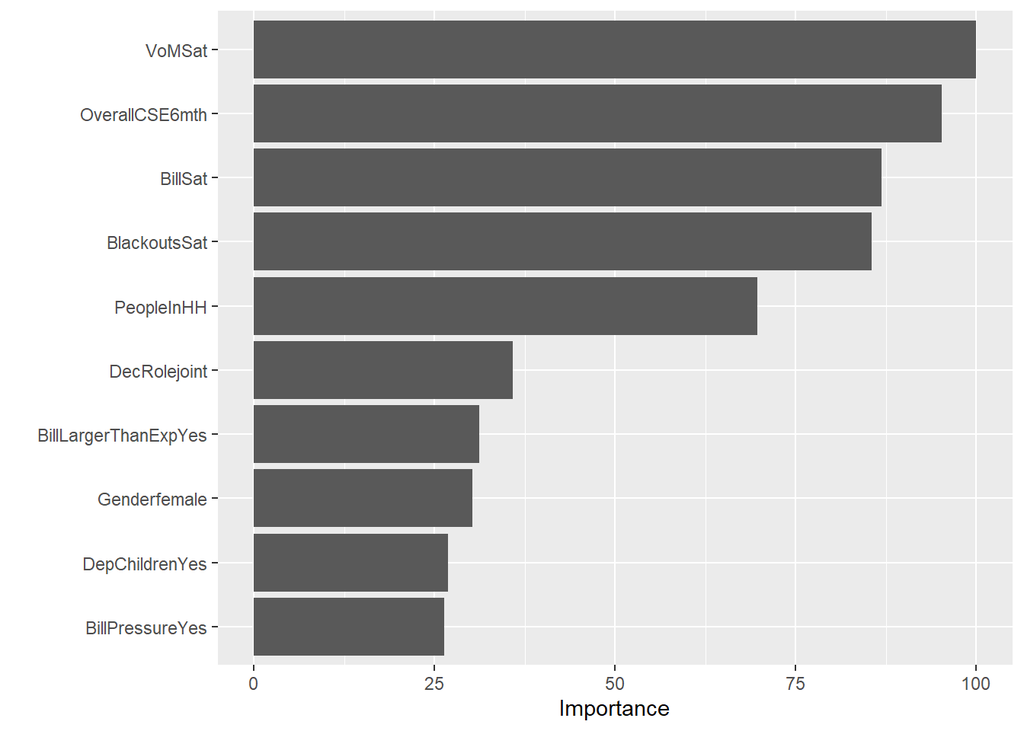

```r
vip(fit5)
```

The bagging algorithm suggests that the most important variables are value for money satisfaction, overall satisfaction, bill satisfaction and satisfaction related to blackouts experienced in the past six months. Compared to the decision tree (which is the base model in this case), bagging suggests that the satisfaction scores play more of a role than other demographics like age and education.

We also assess the predictive accuracy over the test set. Bagging produces the largest precision metric so far.

```r
# Predicting y for the test set
pfit5 <- predict(fit5, newdata=testData, type="prob")
# Assessing model accuracy
fit5Acc=labelAccuracy(testData$Switch,pfit5[,"Yes"],0.5,TRUE)
```

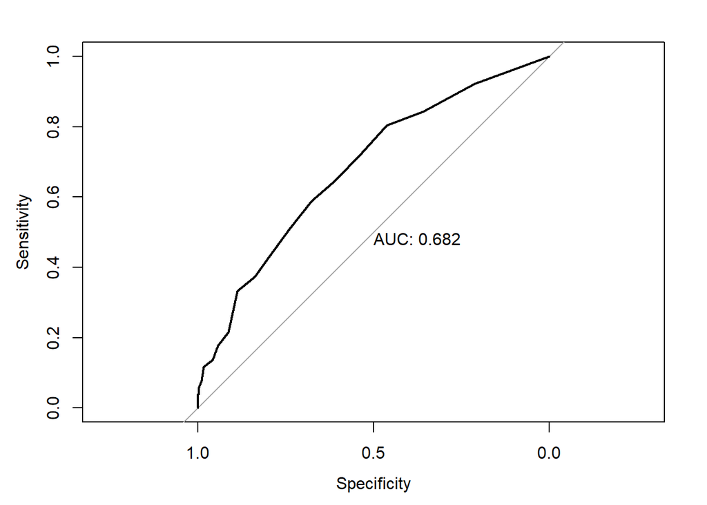

```r
fit5Acc$Metrics
```

```
##        Overall Precision Sensitivity Specificity       AUC      Gini
## [1,] 0.8539604 0.3181818   0.1372549   0.9575071 0.6815253 0.3630506
```

**Random Forest**

The random forest trained using the training data provide another perspective of what variables are important in predicting the intention to switch. Like the case of decision tree, whether or not the consumer feels that their recent bill is larger than expected, and whether they have dependent children are important according to random forest. The two most important variables, however, still relate to consumer satisfaction scores (overall and bill satisfaction).

```r
library(randomForest)
#Set the random seed and train the random forest algorithm
set.seed(123)
fit6 <- randomForest(Switch~., data=trainData, importance=TRUE,
                     ntrees=50, mtry=2)
print(fit6)
```

```
##
## Call:
##  randomForest(formula = Switch ~ ., data = trainData, importance = TRUE,      ntrees = 50, mtry = 2)
##                Type of random forest: classification
##                      Number of trees: 500
## No. of variables tried at each split: 2
##
##         OOB estimate of  error rate: 15.56%
## Confusion matrix:
##       No Yes class.error
## No  1358   6 0.004398827
## Yes  245   4 0.983935743
```

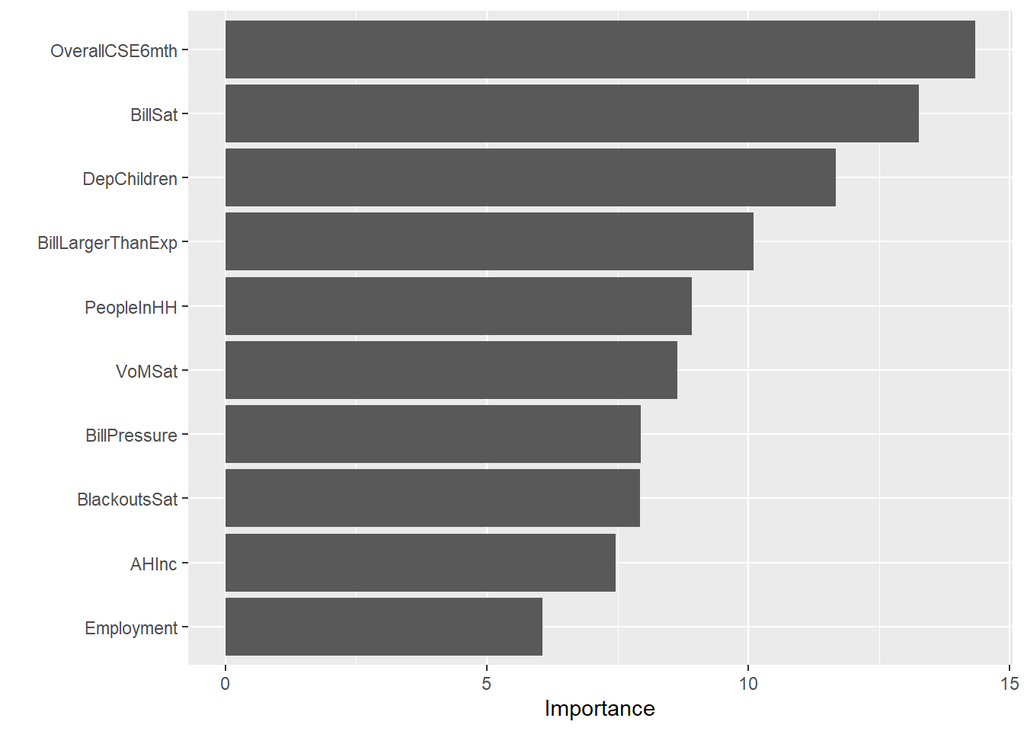

```r
vip(fit6)
```

The test set predictive accuracy measure indicate that random forest has “perfect” precision and specificity. However, its sensitivity is relatively low at 0.02. This indicates that even though all predicted “Yes” turns out to be correct, there are too few of these instances to capture the real occurrences of the intention to switch.

```r
# Predicting y for the test set
pfit6 <- predict(fit6, newdata=testData, type="prob")
# Assessing model accuracy
fit6Acc=labelAccuracy(testData$Switch,pfit6[,"Yes"],0.5,TRUE)
```

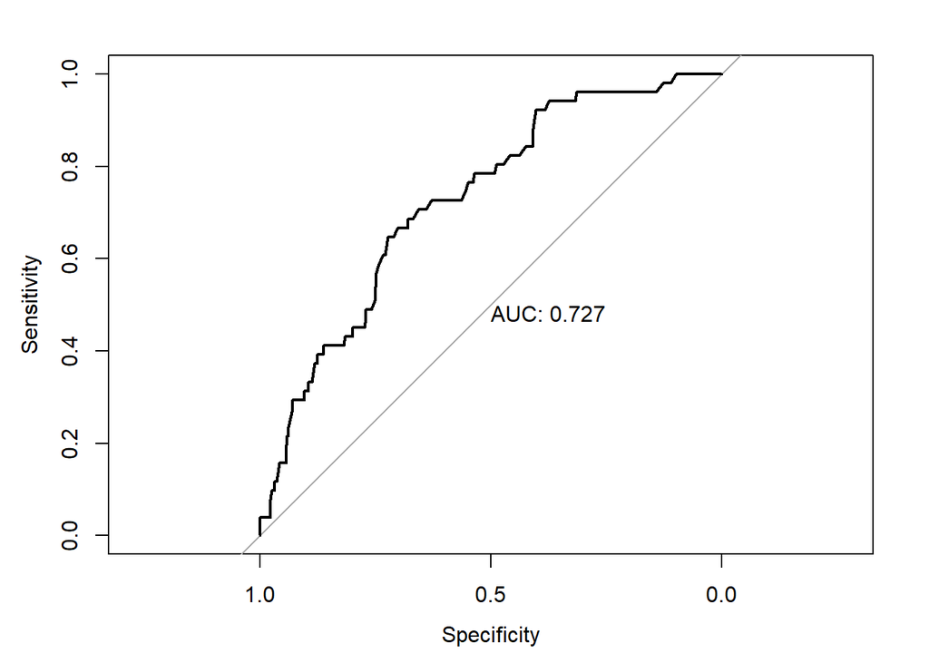

```r
fit6Acc$Metrics
```

```
##        Overall Precision Sensitivity Specificity       AUC      Gini
## [1,] 0.8762376         1  0.01960784           1 0.7267678 0.4535355
```

**Boosting**

The training of the boosting algorithm requires numeric data. In this data set where there are many variables, it is also wise to scale the data prior to training to avoid any numerical issues (this may also aid faster convergence). This is the reason why in the code block below, the scaled data is used in training the model.

```r
library(mboost)
#Set random seed and train he goosing algorithm
#Base model is the logistic regression
set.seed(123)
fit7 <- glmboost(Switch~., data=trainData_scaled, family=Binomial(),
                 control=boost_control(nu=0.1),center = TRUE)
summary(fit7)
```

```
##
##   Generalized Linear Models Fitted via Gradient Boosting
##
## Call:
## glmboost.formula(formula = Switch ~ ., data = trainData_scaled,     family = Binomial(), center = TRUE, control = boost_control(nu = 0.1))
##
##
##   Negative Binomial Likelihood (logit link)
##
## Loss function: {
##      f <- pmin(abs(f), 36) * sign(f)
##      p <- exp(f)/(exp(f) + exp(-f))
##      y <- (y + 1)/2
##      -y * log(p) - (1 - y) * log(1 - p)
##  }
##
##
## Number of boosting iterations: mstop = 100
## Step size:  0.1
## Offset:  -0.850362
##
## Coefficients:
##       (Intercept)       VoMSat_Elec    OverallCSE6mth   BlackoutSatElec
##      -0.200200320      -0.013110516      -0.110065214      -0.016837169
##           EmpHome     EmpUnemployed     JointDecMaker          Age35_44
##       0.009490167      -0.012103174      -0.083916211       0.019666599
##             Age75         Income20k         Income40k        Income150k
##      -0.230172409      -0.028257732       0.018408883       0.056475191
##    EducUniversity      DepChildrenY BillLargerThanExp     BillPressureY
##       0.148639367       0.282499999       0.256212351       0.040587508
##         Townhouse              Unit
##      -0.023528688       0.009485393
## attr(,"offset")
## [1] -0.850362
##
## Selection frequencies:
## BillLargerThanExp             Age75      DepChildrenY    EducUniversity
##              0.13              0.12              0.12              0.11
##    OverallCSE6mth     JointDecMaker       (Intercept)     BillPressureY
##              0.10              0.09              0.05              0.05
##   BlackoutSatElec        Income150k       VoMSat_Elec         Income20k
##              0.04              0.04              0.03              0.03
##          Age35_44         Income40k         Townhouse           EmpHome
##              0.02              0.02              0.02              0.01
##     EmpUnemployed              Unit
##              0.01              0.01
```

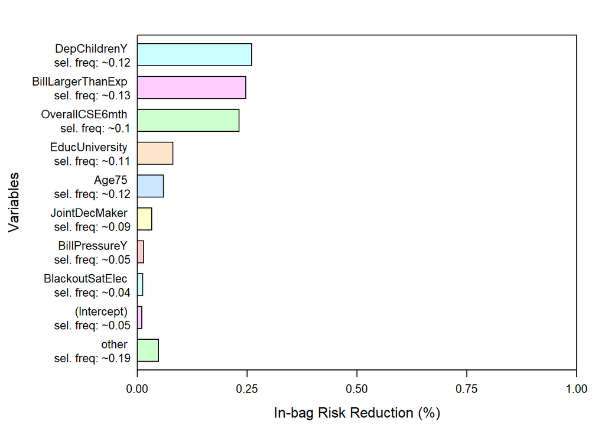

```r
plot(varimp(fit7))
```

The boosting algorithm suggests that the presence of dependence children is most influential, followed closely by the unexpectedly large energy bill and overall consumer satisfaction score. Age and education factors also feature in the top five most influential variables.

```r
# Predicting y for the test set
pfit7 <- predict(fit7, newdata=testData_scaled, type="response")
# Assessing model accuracy
fit7Acc=labelAccuracy(testData$Switch,pfit7[,1],0.5,TRUE)
```

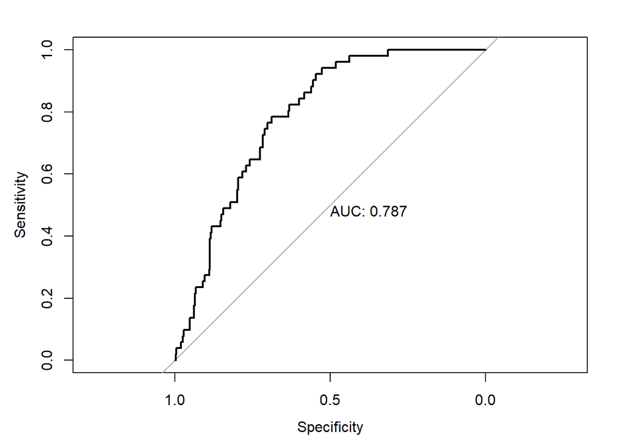

```r
fit7Acc$Metrics
```

```
##        Overall Precision Sensitivity Specificity       AUC      Gini
## [1,] 0.8737624       NaN           0           1 0.7868689 0.5737377
```

The predictive accuracy metric evaluated using the test set reveals that the boosting algorithm fails to predict any “Yes” responses, as indicated by the NaN precision measure. This is actually in line with the results from the logistic regression above, and is not surprising as the logistic regression is the base learner used in this boosting algorithm.

**Support Vector Machine**

Support vector machines can also be used to construct a predictive algorithm for classification. There are three types of algorithms that can handle classification. Here, we use the “C-classification”. As with the case of numeric outcome prediction, the SVM does not provide any sense of interpretation, and is designed only as a predictive machinery. So we will go ahead to assess the predictive outcome using the test set data.

```r
library(e1071)
fit8 <- svm(Switch~., data=trainData_scaled,
            type="C-classification", kernel="linear",
            probability=TRUE,
            scale=FALSE) # use scale false to turn off scaling as dummy variable shouldn't be scaled and use manual scaled data instead
summary(fit8)
```

```
##
## Call:
## svm(formula = Switch ~ ., data = trainData_scaled, type = "C-classification",
##     kernel = "linear", probability = TRUE, scale = FALSE)
##
##
## Parameters:
##    SVM-Type:  C-classification
##  SVM-Kernel:  linear
##        cost:  1
##
## Number of Support Vectors:  734
##
##  ( 485 249 )
##
##
## Number of Classes:  2
##
## Levels:
##  No Yes
```

```r
#Predicting for the test set and extracting predicted probabilities
pfit8 <- predict(fit8, newdata=testData_scaled, probability=TRUE)
pfit8 <- attr(pfit8, "probabilities")
# Assessing model accuracy
fit8Acc=labelAccuracy(testData$Switch,pfit8[,"Yes"],0.5,TRUE)
```

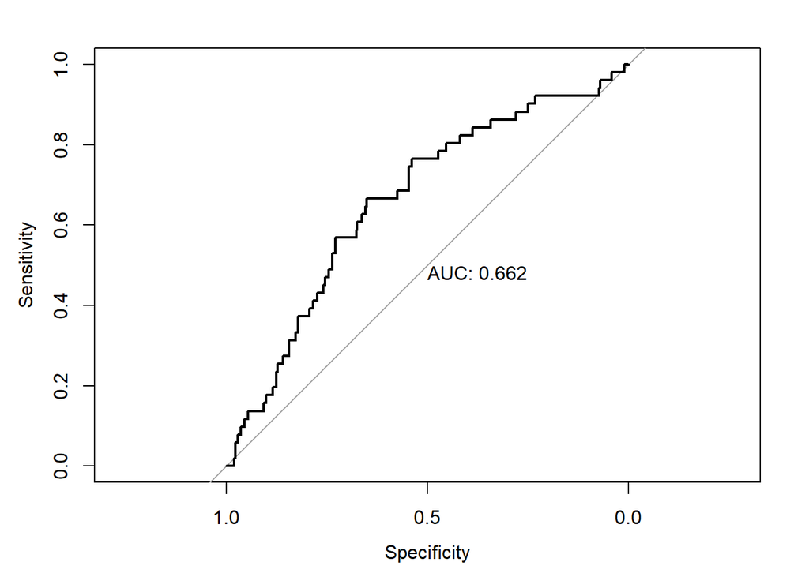

```r
fit8Acc$Metrics
```

```
##        Overall Precision Sensitivity Specificity       AUC      Gini
## [1,] 0.8737624       NaN           0           1 0.6617786 0.3235572
```

At the cutoff probability of 0.5, the SVM algorithm fails to predict any “Yes” responses. Its AUC and Gini index is the second lowest compared to the set of models we considered so far. It should be noted that the SVM is ultimately a segmentation algorithm, and it is not surprising that its performance is not competitive in a problem that has a relatively large number of input variables, most of which are factors variables.

**A summary of test set predictive accuracy**

We collect all predictive statistics below.

```r
allstats=rbind(naiveAcc$Metrics,fit1Acc$Metrics,fit2Acc$Metrics,fit3Acc$Metrics,
               fit4Acc$Metrics,fit5Acc$Metrics,fit6Acc$Metrics,fit7Acc$Metrics,fit8Acc$Metrics)
rownames(allstats)=c("Naive","Logistic","DecisionTree","NeuralNet",
                     "k-NN","Bagging","RandomForest","Boosting","SVM")
allstats
```

```
##                Overall Precision Sensitivity Specificity       AUC      Gini
## Naive        0.8737624       NaN  0.00000000   1.0000000 0.5000000 0.0000000
## Logistic     0.8638614 0.0000000  0.00000000   0.9886686 0.7810920 0.5621841
## DecisionTree 0.8514851 0.2631579  0.09803922   0.9603399 0.6475032 0.2950064
## NeuralNet    0.8168317 0.2195122  0.17647059   0.9093484 0.7314614 0.4629228
## k-NN         0.8737624       NaN  0.00000000   1.0000000 0.6898017 0.3796034
## Bagging      0.8539604 0.3181818  0.13725490   0.9575071 0.6815253 0.3630506
## RandomForest 0.8762376 1.0000000  0.01960784   1.0000000 0.7267678 0.4535355
## Boosting     0.8737624       NaN  0.00000000   1.0000000 0.7868689 0.5737377
## SVM          0.8737624       NaN  0.00000000   1.0000000 0.6617786 0.3235572
```

The collective statistics reveal that one cannot rely on a single predictive accuracy measure here. The most accurate models according to the AUC and the Gini index are the logistic regression and boosting. However, these two models suffer from lack of precision and sensitivity. On balance of precision and sensitivity, bagging and neural network performs best. One might argue that the random forest is also a contender, but as mentioned previously, the small sensitivity measure indicates that it predicts too few “Yes” responses relative to the actual occurrences.

### What is the optimal cutoff?

All predictive assessments above are conducted using the cutoff probability of 0.5. This is the most common choice as probability of 0.5 represents a natural majority/likelihood. However, this may not be the most optimal that gives the most accurate prediction or minimum loss. For example, in disease detection a lower cutoff probability level may be chosen. In this respect, the choice is context driven.

If there is no context that drive this choice, one may consider searching for the optimal cutoff probability as part of the model construction and testing. Let us take the logistic regression model for an example. At the cutoff level of 0.5, the model suffers from lack of precision and sensitivity. Can the prediction be improved if we select another cutoff level? In the code below, we plot precision and sensitivity from the logistic model at different levels of cutoff probabilities.

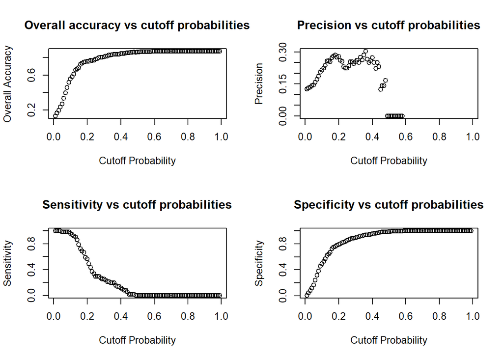

```r
#Set up a grid value of the cutoff
cutoff=seq(from=0.01,to=0.99,by=0.01)
overall=vector(mode="numeric",length(cutoff))
precision=vector(mode="numeric",length(cutoff))
sensitivity=vector(mode="numeric",length(cutoff))
specificity=vector(mode="numeric",length(cutoff))

for(i in 1:length(cutoff)){
  acc=labelAccuracy(testData$Switch,pfit1,cutoff[i],FALSE)
  overall[i]=acc$Metrics[,"Overall"]
  precision[i]=acc$Metrics[,"Precision"]
  sensitivity[i]=acc$Metrics[,"Sensitivity"]
  specificity[i]=acc$Metrics[,"Specificity"]
}

par(mfrow=c(2,2))
plot(x=cutoff,y=overall,xlab="Cutoff Probability", ylab="Overall Accuracy",
     main="Overall accuracy vs cutoff probabilities")
plot(x=cutoff,y=precision,xlab="Cutoff Probability", ylab="Precision",
     main="Precision vs cutoff probabilities")
plot(x=cutoff,y=sensitivity,xlab="Cutoff Probability", ylab="Sensitivity",
     main="Sensitivity vs cutoff probabilities")
plot(x=cutoff,y=specificity,xlab="Cutoff Probability", ylab="Specificity",
     main="Specificity vs cutoff probabilities")
```

```r
#optimal cutoff for precision
cutoff[which.max(precision)]
```

```
## [1] 0.36
```

```r
#optimal cutoff for sensitivity
cutoff[which.max(sensitivity)]
```

```
## [1] 0.01
```

For this particular logistic regression, the optimal cutoff probability for precision is 0.36. The plots also reveal that there is a direct tradeoff between sensitivity and specificity, so if you want to optimize sensitivity, there will inevitably be a reduction in specificity. Logically, this makes complete sense, as lower cutoff probabilities mean that you are casting the net wider to predict the “Yes” response, so you will naturally get higher levels of false positive rates (1-specificity). This tradeoff is actually illustrated by the ROC curve as well.

If the purpose of predicting the intention to switch is to take action to ensure that the switch does not occur, one would want predictions that is accurate in terms of sensitivity. At the same time, precision is also desirable as low levels of precision means that the energy company may end up taking action to intervene consumers who do not intend to switch and generate extra costs that are unnecessary. A middle ground here would be to choose the cutoff probability of 0.18, which results in the second highest precision of 28.6% and a reasonably high sensitivity of 66.7%.

### Out of time robustness - assessing model with June 2020 data

Another important aspect of predictive analytics is robustness assessments of models on “out-of-time” samples. When one can obtain data samples of the same predictive context, but collected at different time points, this procedure allows you to check if the chosen models are robust across time.

Since the energy consumer sentiment survey is conducted every six months, we can assess the out-of-time robustness of the models using June 2020 data. For the purpose of robustness checks, we will explore the robustness of bagging, random forest and neural network, which are the top three performing models from the above predictive assessment. The first step to take is to make sure we have the data structure that matches the December 2019 data, including the scaled version that neural network works with.

```r
#Constructing the scaled version of June 2020 data for testing
jun20_scaled <- jun20

# change categorical variables to dummy
catVar <- model.matrix(~Employment+DecRole+
                        Gender+Age+AHInc+Educ+
                        DepChildren+OwnOrRent+BillLargerThanExp+
                        BillPressure+HouseType, data = jun20_scaled)[,-1]

# scale continuous variables
for (i in 9:13){
    jun20_scaled[,i] <- as.numeric(scale(jun20_scaled[,i]))
}

# combining dummy and scaled variables
jun20_scaled <- cbind(jun20_scaled[, 9:13], catVar,
                       jun20_scaled[,"Switch"])

# rename variables as the existing name is too long
names(jun20_scaled)[] <- c("PeopleInHH", "VoMSat_Elec", "OverallCSE6mth",
                            "BillSatElec", "BlackoutSatElec", "EmpFT", "EmpPT",
                            "EmpHome", "EmpRetired",
                            "EmpUnemployed", "EmpStudent", "JointDecMaker",
                            "Female","Age25_34","Age35_44", "Age45_54",
                            "Age55_64", "Age65_74","Age75", "AgeNoAns", "Income20k",
                            "Income40k", "Income60k", "Income80k",
                            "Income100k", "Income120k", "Income150k",
                            "EducYear12", "EducTAFE", "EducDiploma",
                            "EducUniversity", "DepChildrenY",
                            "OwnHomeY", "BillLargerThanExp", "BillPressureY",
                            "Townhouse","Unit","OtherHouseType",
                            "Switch")
```

In the following section, we retrain the neural network, bagging and random forest using the entire data set from the December 2019 survey. The newly trained models are then applied to predict the “Switch” outcome from the June 2020 survey, and the predictive accuracy metrics recorded.

```r
#Retrain the neural network with the entire data set from December 2019
set.seed(456)
fit3Dec19=neuralnet(Switch~., data=energy_scaled, hidden=4,
                  linear.output = FALSE)
pfit3Jun20 <- predict(fit3Dec19, newdata=jun20_scaled)[,2]
# Assessing model accuracy
fit3AccJun20=labelAccuracy(jun20$Switch,pfit3Jun20,0.5,TRUE)
```

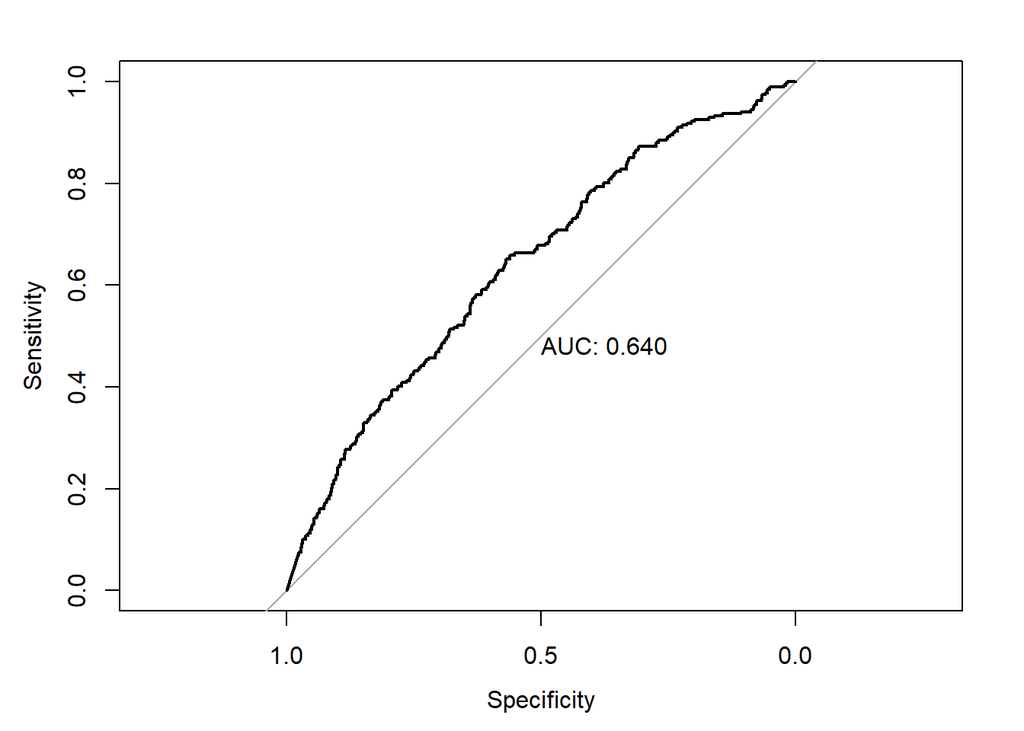

```r
#Retraining the bagging algorithm using the entire data set from December 2019
set.seed(456)
fit5Dec19 <- train(Switch~., data = dec19, method='treebag',
              metric="Accuracy")
pfit5Jun20 <- predict(fit5Dec19, newdata=jun20, type="prob")[,2]
# Assessing model accuracy
fit5AccJun20=labelAccuracy(jun20$Switch,pfit5Jun20,0.5,TRUE)
```

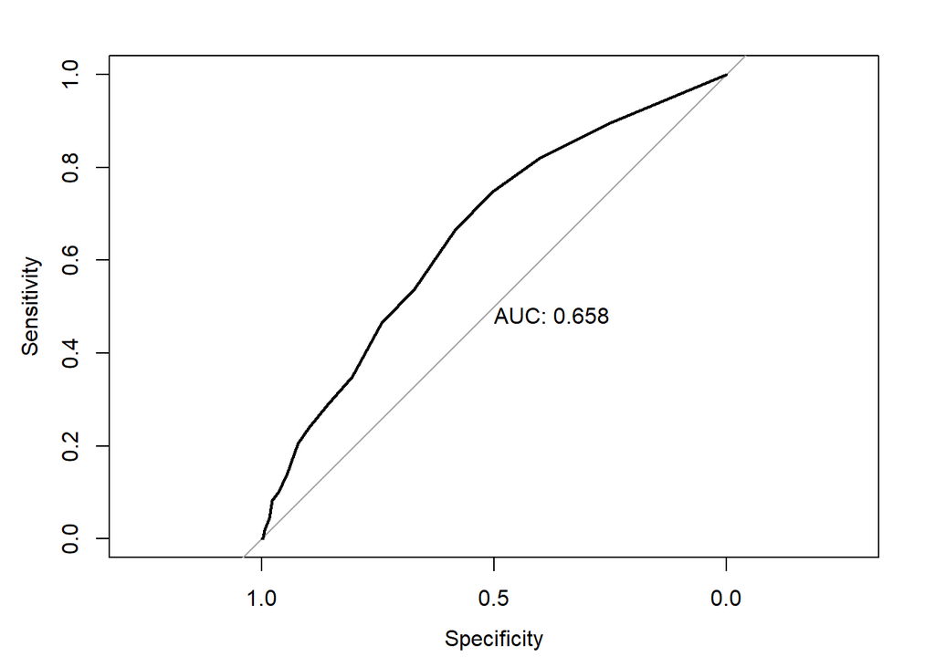

```r
#Retraining the random forest using the entire data set from December 2019
set.seed(456)
fit6Dec19 <- randomForest(Switch~., data=dec19, importance=TRUE,
                     ntrees=50, mtry=2)
pfit6Jun20 <- predict(fit6Dec19, newdata=jun20, type="prob")[,2]
# Assessing model accuracy
fit6AccJun20=labelAccuracy(jun20$Switch,pfit6Jun20,0.5,TRUE)
```

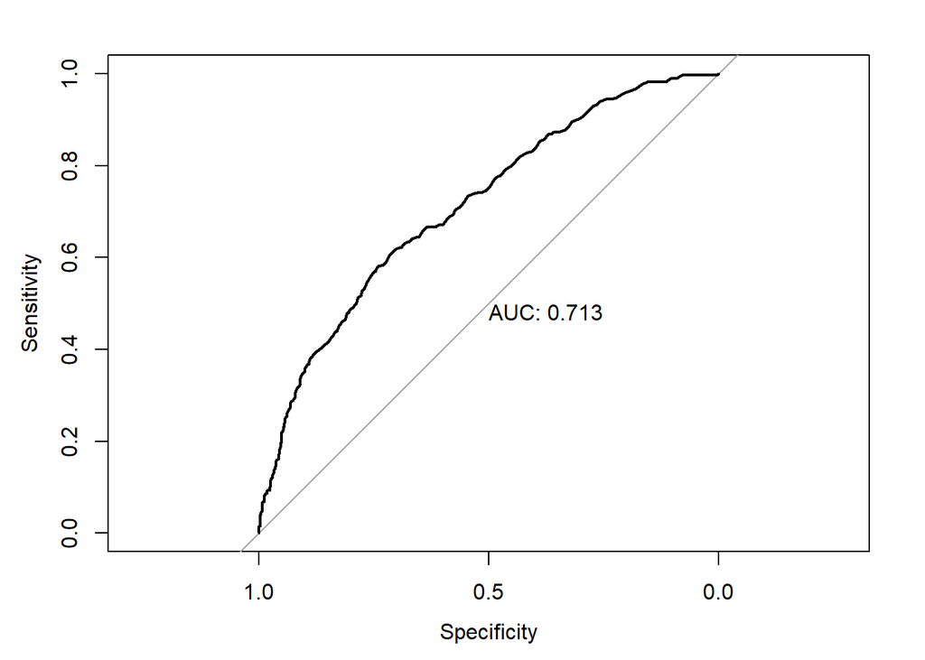

```r
accJun20=rbind(fit3AccJun20$Metrics,fit5AccJun20$Metrics,fit6AccJun20$Metrics)
rownames(accJun20)=c("NeuralNet","Bagging","RandomForest")
accJun20
```

```
##                Overall Precision Sensitivity Specificity       AUC      Gini
## NeuralNet    0.8146293 0.2648402  0.21722846   0.9068826 0.6403855 0.2807711
## Bagging      0.8577154 0.3606557  0.08239700   0.9774436 0.6580507 0.3161014
## RandomForest 0.8667335 0.5714286  0.01498127   0.9982649 0.7134701 0.4269403
```

The predictive accuracy metrics (using the cutoff probability of 0.5) from the June 2020 data reveal that the predictive performance of bagging and neural network are reasonably robust, but with lower sensitivity from bagging. The random forest, however, suffer from a reduction in both precision and sensitivity and can be concluded to be the least robust of the three models considered here.

**What has changed between December 2019 and June 2020?**

Let us conclude by looking into what has changed through the lens of the random forest.

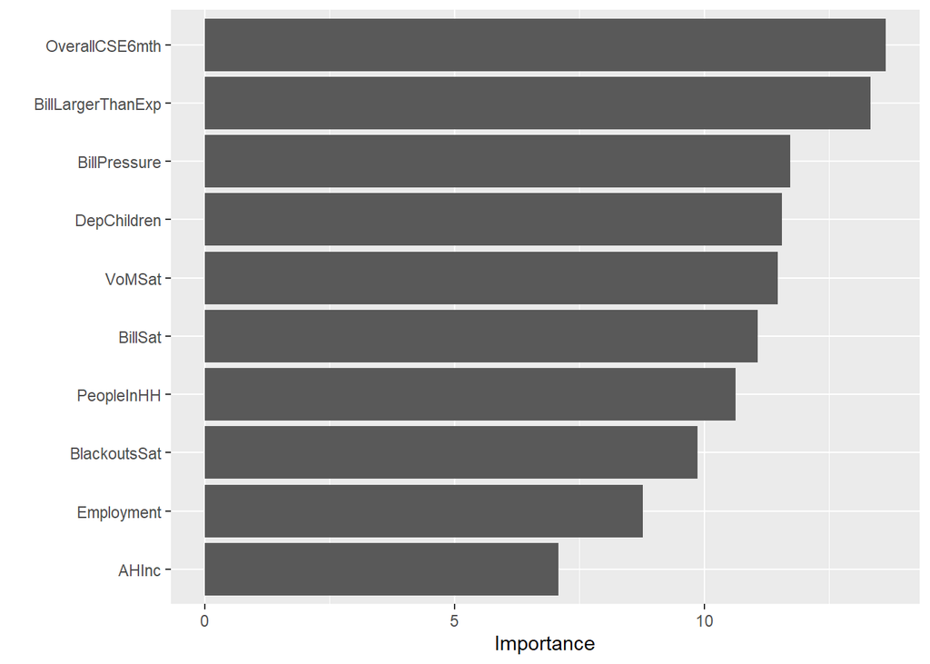

```r
#Retrain the random forest with June 20 data
set.seed(123)
fit6Jun20<- randomForest(Switch~., data=jun20, importance=TRUE,
                     ntrees=50, mtry=2)

#Comparing the variable importance plots from Dec 19 and Jun 20
vip(fit6Dec19)
```

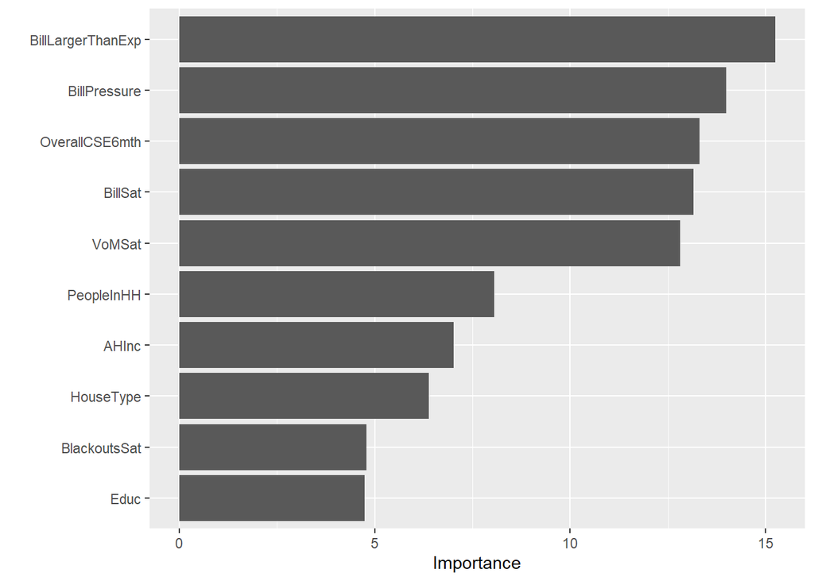

```r
vip(fit6Jun20)
```

**We see here that the tools covered in this subject is generally applicable to both numerical and classification/label data. However, in assessing predictive accuracy, considerations around the performance metrics are different. The key factor in making these predictive tool most effective is a thorough understanding of the context of the business problem and how the final predictive outcome is going to be implemented in practice.**